# Rigsrevisionen Workshop on Computational Text Analysis

# Chaining

In previous segments, we saw that it is possible to transform a dataset by creating new columns by referencing or by grouping the different entries of a dataset based on certain attributes and aggregation functions applied on these. In most data languages, the application of new functions on the results of such operations generally involves adding new command lines to scripts and the consequent creation of so-called intermediate tables, tables whose sole function is to allow the compilation of subsequent tables. Such a way of proceeding is, however, very costly in terms of time and processing space. However, some packages offer users an interesting alternative in terms of sequential processing: chaining. By chaining, we mean here the possibility of creating sequences of operations on the same object and within a single command. In other words, rather than creating intermediate objects, it is possible to perform successive operations on a single table. Although the *data.table* package offers such functionality here, we believe it is much simpler and more intuitive to present to you here the “pipe” operator (*%>%*) of the *magrittr* package, which can be used to both for reassignment and chaining. Syntactically, such a procedure is carried out as follows:

```r
DT %>%
  [ ... ] %>%
  .[ ... ] %>%
  .[ ... ]...
```

According to this diagram, *%>%* is first used to assign subsequent operations to the DT object, the sequence of which is ensured by the subsequent uses of **%>%**, but also by the use of the point (**.**), whose function here is to indicate that the following procedure must apply to the result of the previous procedure, an instruction having no direct equivalent in the *data.table library* . This procedure is of course hybrid, but it nevertheless has the advantage of combining the performance and syntactic simplicity of *data.table* with the intuitive assignment and chaining of the **%>%** operator. More generally, such a type of chaining makes it possible to achieve significant gains not only in terms of code writing and readability, but also in terms of space and processing time required, since the chaining of operations reduces the number intermediate tables created during data processing processes. As an example, different frequency distributions can be reordered quickly and simply by chaining, or by using the *order()* function in the *i* argument of the second pair of brackets.

```r
corpus[, .(tokens = .N, types = uniqueN(token)),
       by = .(department)] %>%
  .[order(tokens, decreasing = TRUE)]
```

The sorting of these frequency distributions actually represents only one case among a range of more complex operations that can be carried out in one go by command chains. Indeed, any function following the grouping operation performed in *by* can be chained to the command performing the grouping using the combined use of pipe and point

```r
all.equal(corpus[, .(tokens = .N, types = uniqueN(token)),
                 by = .(department)] %>%
            .[order(tokens, decreasing = TRUE)] %>%
            .[(1:5)],
          head(corpus[, .(tokens = .N, types = uniqueN(token)),
                 by = .(department)] %>%
            .[order(tokens, decreasing = TRUE)], n = 5))
```

```
## [1] TRUE
```

The joint use of grouping and chaining functions allows you to quickly restore corpus sentences and paragraphs from the tokens kept for analysis in the tagged corpus. Let’s first start by restoring the text of each sentence of each document paragraph. To this end, we’ll use the *paste()* function, which allows you to concatenate character strings and whose *collapse* argument allows you to specify the characters to be inserted between each join.

```r
raw_corpus <-
  corpus[, .(document_text = paste(token, collapse = ' ')),
         by = .(id, aktstk_nr, paragraph_id, sentence_id)]
```

This corpus restitution exercise highlights a fundamental aspect of computer-assisted text analysis: the return to the text. Like all expert reading, there is no definitive, predetermined computer-assisted text analysis procedure; there are of course general rules, but the choice of a particular approach is the result of an often spontaneous and interactive procedure, guided by the results obtained at each of the many stages of treatment. However, such evaluations or validations can only be done by returning to the text, by means of a thoughtful and comparative analysis of the corpus before and after each manipulation. These considerations on the importance of returning to text are an opportunity to introduce you to one of the most fundamental textual analysis and visualization tools in the field, namely concordance.

## Concordance

Concordance (*concordance* or *keyword in context (kwic)* in English) is an old exegetical technique used in philology and consisting of facilitating the semantic analysis of a document or a corpus by the complete listing of lexical contexts minimum occurrence of a word or a group of words within the same document, which can be annotated and commented on as desired by the reader. Before the appearance of computers, creating a concordance, even if only for a single word, was certainly not an easy task, which may explain why only a few texts are subject to it, mainly a few texts sacred and classical secular works. The appearance of automatic concordance generation tools, called concordancers, has however changed the situation, by making it possible to quickly and simply draw up an inventory of the contexts of use of one or more words.

```r
raw_corpus[document_text %like% 'mink']
```

The second, much simpler and faster, is based on the combined use of filtering and grouping operations on the annotated corpus.

By means of a procedure similar to that used for the reconstruction of the corpus, it is possible to extract information relating to the occurrence of the target word and to reconstruct the sentences in question by means of grouping by documents, paragraphs and sentences . To do this, we only keep the information relating to the sentences containing the target word and then reconstitute them by grouping.

```r
corpus[token %like% 'mink', .(id, paragraph_id, sentence_id)] %>%
  merge(., corpus, by = c('id', 'paragraph_id', 'sentence_id')) %>%
  .[, .(word_context = paste(token, collapse = " ")), by = id] %>%
  .[, word_context]
```

However, if the second method is faster and simpler to understand than the first, it is however much less flexible: while the first method allows you to precisely specify the substring of characters to search for as well as the extent of the substrings. character strings preceding and following the searched expression, the second only returns whole words and sentences. It is true that it is possible to control the extent of these windows using the *token_id* attribute, but this will complicate the function. Note also that the cleaning operations carried out on the raw corpus must also be applied after execution of the second method. Each method therefore has its advantages and disadvantages; It’s up to you to choose the one that best suits your needs, and nothing prevents you from using the functions defined in the libraries mentioned above. One thing is certain, however: regardless of your research objectives, concordance generation will definitely be part of your analysis tools.

## exercises

1. Get, for each department and upos tag, Obtenez, pour chaque source et type de publication, the most frequent token.

```r
# Write your code here
```

2. Get, for each department and upos tag, Obtenez, pour chaque source et type de publication, the most frequent type

```r
# Write your code here
```

4. Get the concordance of a word of your choice using one of the methods described above

```r
# Write your code here
```

# Visualization

Although it is possible to directly insert visualization functions in *j*, data visualization is generally the last step in a more or less long series of operations and groupings on one or more attributes and requiring the creation of several intermediate datasets. As we saw in the previous segment, it is however possible to chain such processing sequences within a single command, through the joint use of the pipe and the point. Like other more complex procedures, the data visualization functions as well as the processing operations which underlie them can thus be easily embedded within a single command via such chaining.

For data visualization, we will use the excellent *ggplot2* library, developed by Hadley Wichkam and based on the graphics grammar developed by Leland Wilkison in his book *The grammar of graphics* (Wilkinson 2005). The particularity of this grammar is that it uses an additive syntax, based on a basic schema on which different layers of visualization parameters can be superimposed.

```r
- GGPlot:
  - data
    - *ggplot2* allows to work only with data frames (nb: a data table is a type of data frame)
  - aesthetics (*aes()*)
    - Aesthetic projection of the variables to visualize.
      - Coordinates, colors, sizes, shapes...
  - geometry (*geom_*)
    - Geometrical object(s) used for visualizing data (point, line, multi-line, polygon, multi-polygon)
  - other optional layers...
    - *stat*: statistical transformation of data to visualize
    - *scale_*:  espace esthétique (couleurs, formes, tailles, axes, légendes)
    - facets (*facet_wrap*, *facet_grid*): visual distribution of data using subplots
```

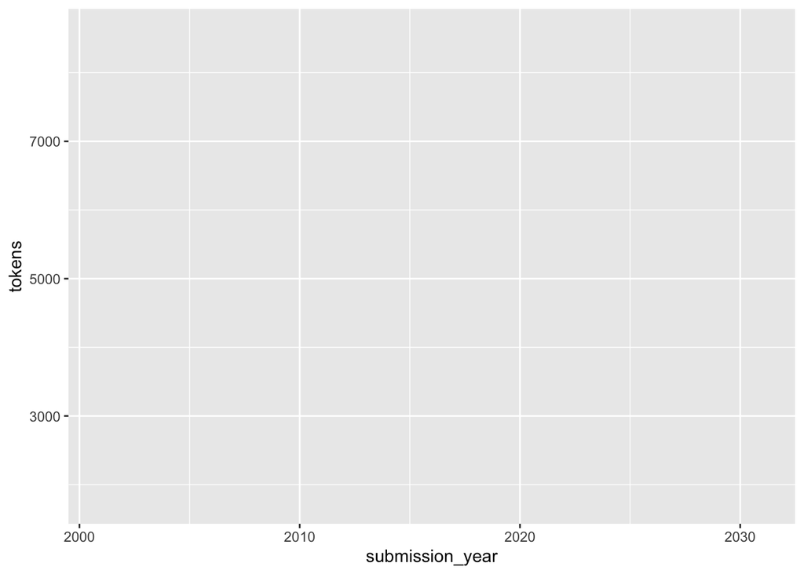

```r
corpus[, .(tokens = .N),
       by = .(submission_year)] %>%
  .[order(tokens, decreasing = TRUE),] %>%
  ggplot2::ggplot() +
  ggplot2::aes(y = tokens,
               x = submission_year)
```

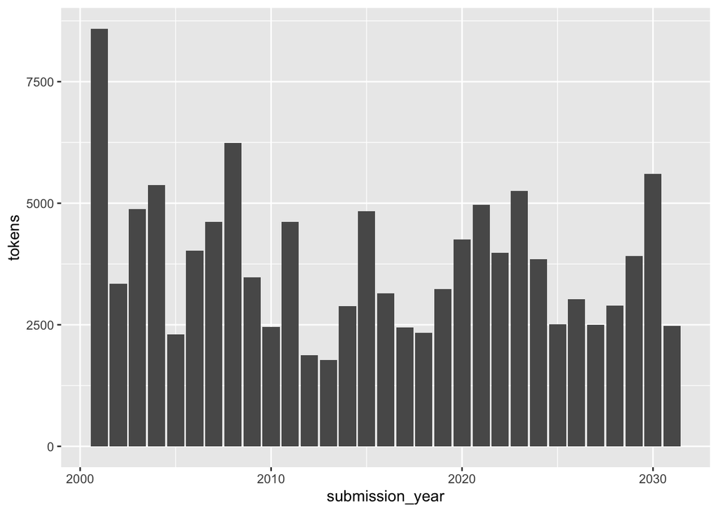

```r
corpus[, .(tokens = .N),
       by = .(submission_year)] %>%
  .[order(tokens, decreasing = TRUE)] %>%
  ggplot2::ggplot(ggplot2::aes(y = tokens,
                               x = submission_year)) +
  ggplot2::geom_col()
```

The *ggplot* library allows you to carry out a first visualization of your data very quickly and easily. You can then modify your graph as needed incrementally, by adding new layers to your command.

If it is quick and easy to visualize such a frequency distribution, what about when it comes to visualizing several variables? For example, when it comes to adding to the previous visualization the number of lexical types per source? As with other libraries included in the *tidyverse*, a collection of extensions designed to work together and based on a common philosophy, *ggplot* assumes that the input datasets are “clean” (**tidy** ). Concept developed by Hadley Wickham and derived from the third normal form (3FN) of Codd’s relational algebra, the “cleanliness” of clean data sets (*tidy*) is based on respecting the following three principles:

1. Each variable constitutes a column
2. Each observation constitutes a line
3. Each type of observation is in a separate table

As an example, consider again the frequency distribution of lexical types and occurrences in the corpus.

```r
corpus[, .(tokens = .N, types = uniqueN(token)),
       by = .(submission_year)] %>%
  .[order(tokens, decreasing = TRUE)]
```

```r
corpus[, .(tokens = .N, types = uniqueN(token)),
       by = .(submission_year)] %>%
  .[order(tokens, decreasing = TRUE)] %>%
  data.table::melt(.,
                   id.vars = 'submission_year',
                   variable.name = 'lexical_category',
                   value.name = 'frequency')
```

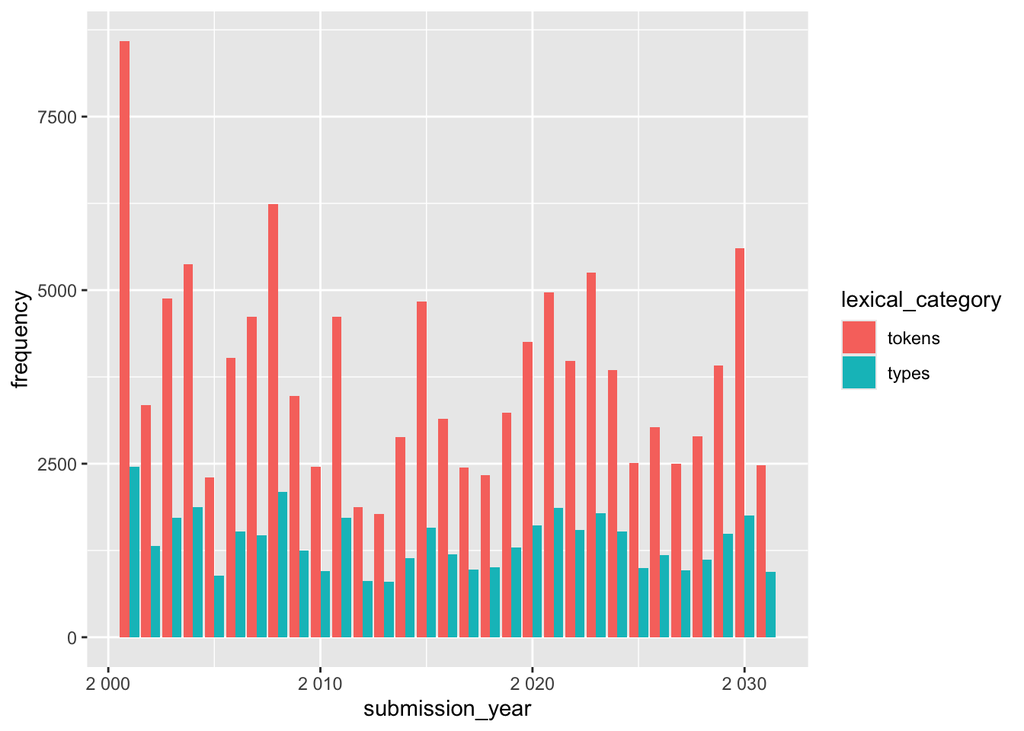

```r
corpus[, .(tokens = .N, types = uniqueN(token)),
       by = .(submission_year)] %>%
  .[order(tokens, decreasing = TRUE)] %>%
  data.table::melt(.,
                   id.vars = 'submission_year',
                   variable.name = 'lexical_category',
                   value.name = 'frequency') %>%
  ggplot2::ggplot(ggplot2::aes(y = frequency,
                               x = submission_year,
                               fill = lexical_category)) +
    ggplot2::geom_col(position="dodge") +
    ggplot2::scale_x_continuous(
      labels=function(x) format(x,
                                big.mark = " ",
                                scientific = FALSE))
```

Finally, one of the advantages of data visualization is that it offers a synthetic view of data sets and often allows statistical regularities and anomalies to be identified more quickly than analytical methods in the strict sense. To remain within the framework of lexical statistics, an obvious case is the bilogarithmic representation of frequency-rank distributions.

Frequency-rank distributions represent a special type of lexical distribution, in which all lexical types are reduced to both their cardinal and ordinal form: each lexical type is converted to a pair of numbers representing its frequency and rank in the distribution decreasing frequency. The use of these distributions dates back to the work of Jean-Baptiste Estoup (Estoup 1912), a specialist and teacher of the Duployé system, a stenographic method based on a geometric phonetic alphabet initially designed for the education of illiterates. In order to enable his students to write shorthand as quickly as possible at a speed close to that of the spoken language, Estoup sets himself the goal of finding which words are most frequent in different contexts and of designing exercises adapted to lexical frequencies. natural language. To do this, Estoup extracts lexical frequency distributions from different oratory and epistolary contexts in order to measure for each successive segment of 1000 words, the number of distinct words, their frequency in descending order as well as their average repetition rate. These first frequency-rank distributions and the visualizations that accompany them constitute the first observations relating to the hyperbolic nature of lexical usage, according to which a handful of very frequent words account for the majority of lexical occurrences in any linguistic sample.

Estoup’s empirical and methodological work was taken up independently by Condon (Condon 1928) and Zipf (Zipf 2002), who discovered that the relationship between lexical types and their frequency is constant over entire distributions. Data visualization played a crucial role in this research: by representing lexical frequencies and ranks on logarithmic axes, the two authors managed to demonstrate that the slope of the line thus formed is surprisingly linear and therefore that the relationship between the variables is surprisingly constant over all distributions. This discovery will also lead Zipf to formulate his famous eponymous law, according to which the frequency of occurrence *f(n)* of a word in a text is linked to its rank *n* in the order of frequencies by a law of the form ${\displaystyle f(n)={\frac {K}{n}}}$ where K is a constant. This “law” will be the subject of numerous critiques, uses and revisions, the most famous being its reformulation in canonical form by Bruno Mandelbrot (Mandelbrot 1951).

Of interest for our present purposes, however, several researchers have used frequency-rank distributions and particularly their bilogarithmic representation to evaluate and compare the lexical diversity of different texts. According to such an interpretation and use, the steeper the slope of the line, the more concentrated the vocabulary of the corresponding text. To give you an example of use taken from our corpus, let’s start by grouping the terms by source and decreasing order of frequency, delete the terms column then add the rank of the frequencies grouped by source using the *frankv* function of *data.table*

```r
corpus[, .(tokens = .N),
       by = .(submission_year,
              token)] %>%

  .[, rank := data.table::frankv(tokens,
                                order = -1),
    by = submission_year] %>%
  .[, token := NULL] %>%
  .[order(rank, decreasing = FALSE)]
```

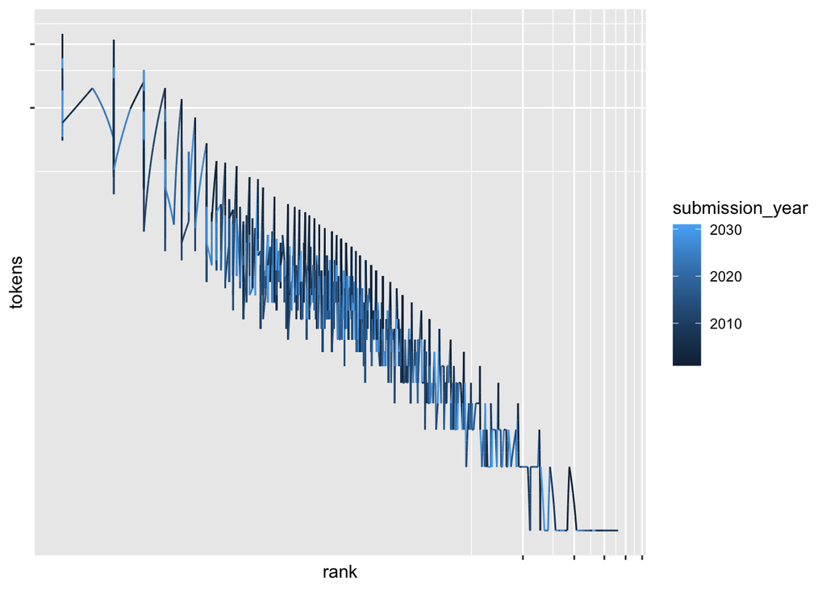

```r
corpus[, .(tokens = .N),
       by = .(submission_year,
              token)] %>%

  .[, rank := data.table::frankv(tokens,
                                 order = -1),
    by = submission_year] %>%
  .[, token := NULL] %>%
  .[order(rank, decreasing = FALSE)] %>%

  ggplot2::ggplot(ggplot2::aes(x = rank,
                               y = tokens,
                               color = submission_year)) +
    ggplot2::geom_line() +
    ggplot2::coord_trans(x = 'log10', y = "log10") +
    ggplot2::theme(axis.text.x = ggplot2::element_blank(),
                   axis.text.y = ggplot2::element_blank())
```

These few blocks of code show you how easy and quick it is to carry out a first corpus analysis and to carry out first data visualizations by means of the joint use of the *data.table*, *magrittr* and * libraries. ggplot2*. However, two points should be mentioned here. First of all, a structured, cleaned and annotated corpus like the one used here is a finished product: like the polishing and cutting of a jewel, a corpus does not exist in its raw state, the documents which it includes must be previously extracted and subjected to different types of processing, particularly linguistic. Certainly one of the most crucial and time-consuming stages of text mining, corpus pre-processing will be the subject of the next lesson. Another important point: with the explanation by font and the visualization of the variables of the frequency distributions of occurrences, frequency ranks and lexical types, we strictly speaking leave the domain of univariate analysis. Although useful, univariate analysis remains limited in scope and can only offer a “surface view” of a corpus, one variable at a time. In the courses that follow, more advanced mathematical and statistical techniques and models, based on the consideration of more than one variable and allowing more detailed textual analyses, will be presented to you.

## Exercises

1. Get, for each submission year and document status, the number of distinct documents and visualize the results with a grouped bar chart

```r
# Write your code here
```

2. Get the token count and type count for each upos tag in the corpus. Visualize the results using a grouped bar chart.

```r
# Write your code here
```

# References

Condon, Edward U. 1928. “Statistics of Vocabulary.” *Science* 67 (1733): 300.

Estoup, J.-B. 1912. *Gammes Sténographiques*. Paris: Institut sténographique de France.

Mandelbrot, Benoı̂t. 1951. “Adaptation d’un Message à La Ligne de Transmission. I & II.” *Comptes Rendus (Paris)* 232: 1638–2003.

Wilkinson, L. 2005. *The Grammar of Graphics*. Berlin: Springer Science & Business Media.

Zipf, G. K. 2002. *The Psycho-Biology of Language: An Introduction to Dynamic Philology*. Oxon, UK: Routledge.